# ft-SNE

March 3, 2019

Up: [Documentation Home](https://jlmelville.github.io/smallvis/).

Im, Verma and Branson investigated replacing the Kullback Leibler divergence in t-SNE with other [f-divergences](https://arxiv.org/abs/1811.01247), with [Theano code on github, collectively referred to as ft-SNE](https://github.com/jiwoongim/ft-SNE)). The basic t-SNE code seems to be a fork of the thesne code base created to implement [dynamic t-SNE (pdf)](http://www.cs.rug.nl/~alext/PAPERS/EuroVis16/paper.pdf) (a technique for embedding time series data).

The new divergences considered are:

- The “reverse” KL divergence, similar to that considered as part of the [NeRV](http://www.jmlr.org/papers/v11/venna10a.html) method.
- The Jensen-Shannon divergence, similar to that considered in [JSE](https://dx.doi.org/10.1016/j.neucom.2012.12.036).
- The chi-squared divergence.
- The Hellinger distance divergence.

Although we’ve look at something similar for some of these divergences when we implementing [JSE and NeRV](https://jlmelville.github.io/smallvis/nervjse.html), there are some differences with this approach:

- The JSE cost function allows for the relative weighting in the cost function to change with the forward or reverse KL divergence being the limiting value as their weighting function goes to 0 or 1.
- JSE and NeRV use a Gaussian kernel rather than the t-distribution.
- JSE and NeRV row-normalize probabilities as in the original SNE, rather than the symmetrized and matrix-normalized probabilities of t-SNE.

## Cost Functions and Gradients

Here are the cost functions and the gradients for the different divergences. I have gone into more [detail about deriving them elsewhere](http://jlmelville.github.io/sneer/gradients.html). Unlike t-SNE they don’t really simplify into anything nice.

### RKL-SNE

The reverse KL-divergence:

$$C = \sum_{ij} q_{ij} \log \frac{q_{ij}}{p_{ij}}$$

$$\frac{\partial C}{\partial \mathbf{y_i}} =
4 \sum_j
\left[
\left\{ \log \left( \frac{p_{ij}}{q_{ij}} \right) + C \right\} q_{ij}w_{ij}
\right]
\left(
\mathbf{y_i - y_j}
\right)$$

where $C$ is the reverse KL cost function defined above.

### JS-SNE

The Jensen-Shannon divergence:

$$C = \frac{1}{2} \sum_{ij} p_{ij} \log{\left(\frac{p_{ij}}{z_{ij}}\right)} + q_{ij} \log\left({\frac{q_{ij}}{z_{ij}}}\right)$$

where:
$$z_{ij} = \frac{1}{2} \left(p_{ij} + q_{ij} \right)$$

$$\frac{\partial C}{\partial \mathbf{y_i}} =
2 \sum_j
\left[
\left\{ \log \left( \frac{z_{ij}}{q_{ij}} \right) + KL_{Q||Z} \right\} q_{ij}w_{ij}
\right]
\left(
\mathbf{y_i - y_j}
\right)$$

where $KL_{Q||Z}$ is the Kullback-Leibler divergence of Z from Q. There’s a factor of one-half that reduces the usual 4 to 2 in the gradient.

### CH-SNE

The $\chi^2$-divergence:

$$\frac{\partial C}{\partial \mathbf{y_i}} =
4 \sum_j
\left[
\left( \frac{p_{ij}^2}{q_{ij}^2} - \sum_{kl} \frac{p_{kl}^2}{q_{kl}} \right) q_{ij}w_{ij}
\right]
\left(
\mathbf{y_i - y_j}
\right)$$

### HL-SNE

The Hellinger distance divergence:

$$C = \sum_{ij} \left(\sqrt{p_{ij}} - \sqrt{q_{ij}}\right)^2$$

$$\frac{\partial C}{\partial \mathbf{y_i}} =
4 \sum_j
\left[
\left( \frac{\sqrt{p_{ij}}}{\sqrt{q_{ij}}} - \sum_{kl} \sqrt{p_{kl}q_{kl}} \right) q_{ij}w_{ij}
\right]
\left(
\mathbf{y_i - y_j}
\right)$$

## Datasets

See the [Datasets](https://jlmelville.github.io/smallvis/datasets.html) page. Note that although the ft-SNE paper uses a 6,000 subsample of MNIST, it differs from the dataset we use here, in that they sample from the first five digits, whereas the one used below samples from all ten digits.

## Settings

The ft-SNE paper examples use large values of perplexity: for example, 300 for the Isomap faces (which has N = 698), and 2000 for the 6,000 subsample of MNIST. This differs from the usual t-SNE practice, but makes sense from the point of view of using divergences that emphasise global structure rather than focussing on local neighborhoods. It also calls into question whether early exaggeration should be used, although it turns out not to make much difference, so for consistency with the KL divergences, I keep it in the examples below. The dynamic t-SNE code doesn’t use early exaggeration of DBD optimization, but does use the momentum switch and also uses a learning rate switch (which by default reduces the learning rate by a factor of 10). The ft-SNE keeps this basic setup, but also implements learning rate and momentum decay, although the momentum decay only occurs before the momentum switch.

To deal with the issue of what perplexity to use, we will look at two perplexities with RKL-SNE: the standard `perplexity = 40`, and a then a dataset dependent perplexity of N / 3. This is substantially larger than usual for all datasets (except `iris`, where N / 3 = 50).

DBD optimization with the usual learning rate of `eta = 100` worked well for all divergences, except CH-SNE, where `eta = 10`.

```
iris_chsne <- smallvis(iris, method = "chsne", perplexity = 40, eta = 10, Y_init = "spca", exaggeration_factor = 4)
iris_hlsne <- smallvis(iris, method = "hlsne", perplexity = 40, eta = 100, Y_init = "spca", exaggeration_factor = 4)
iris_jssne <- smallvis(iris, method = "jssne", perplexity = 40, eta = 100, Y_init = "spca", exaggeration_factor = 4)
iris_rklsne <- smallvis(iris, method = "rklsne", perplexity = 40, eta = 100, Y_init = "spca", exaggeration_factor = 4)
```

## Results

### iris

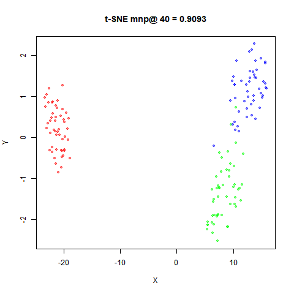

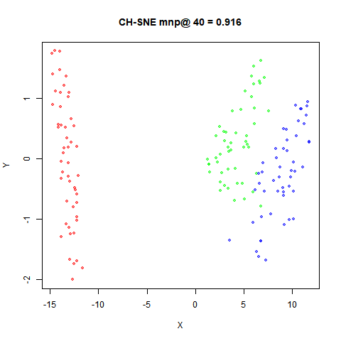

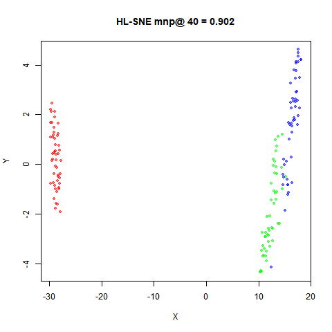

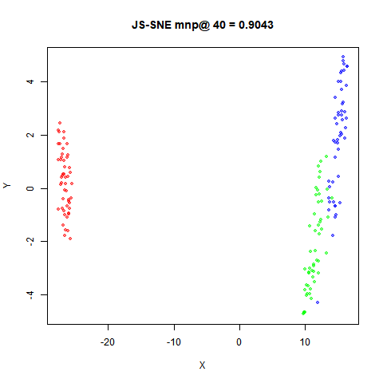

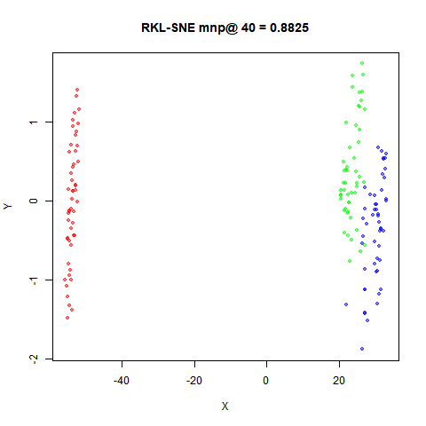

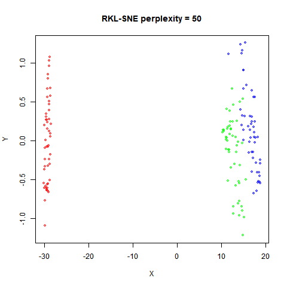

### s1k

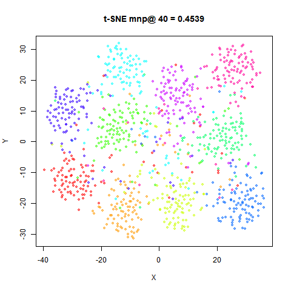

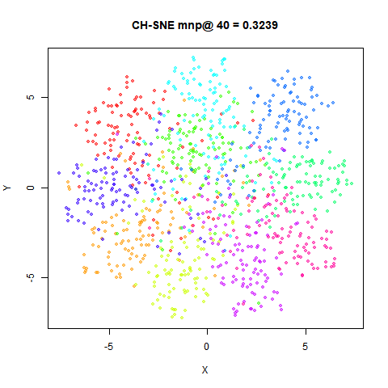

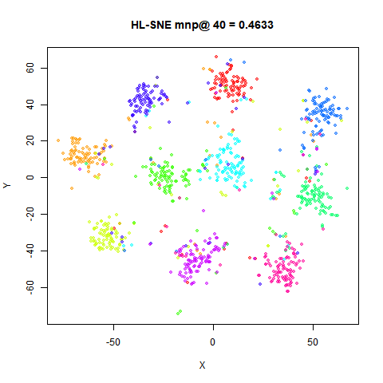

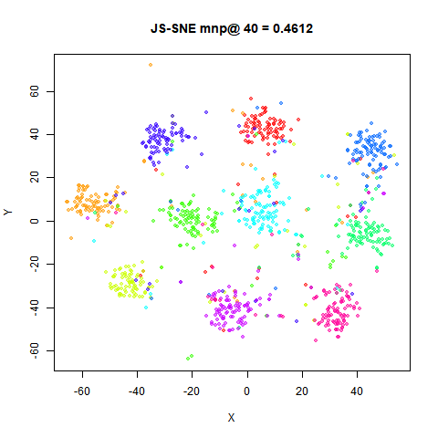

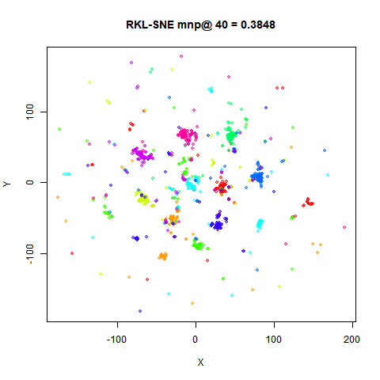

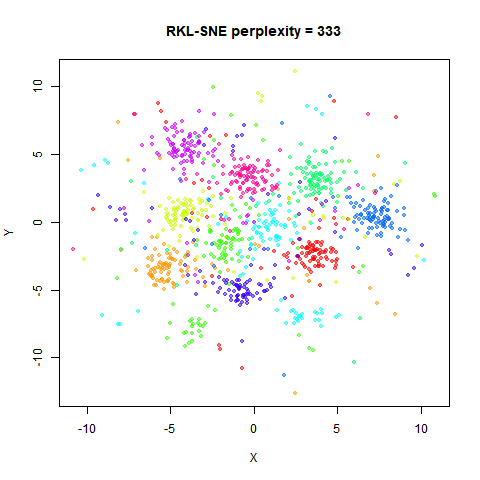

### oli

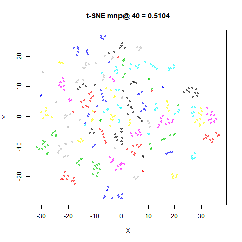

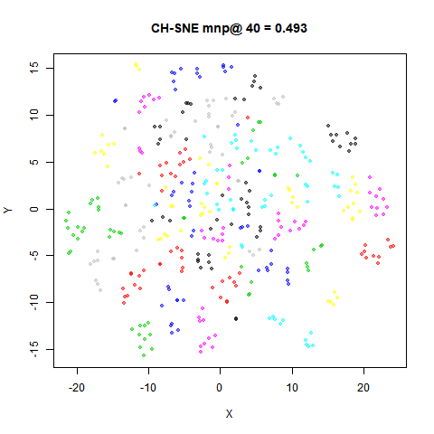

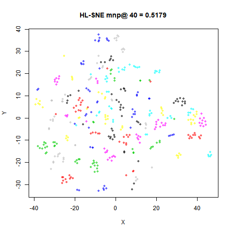

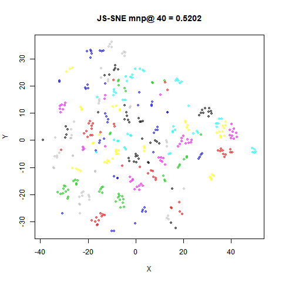

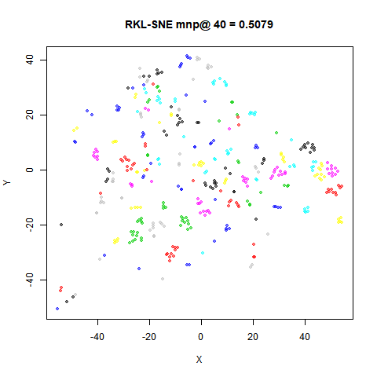

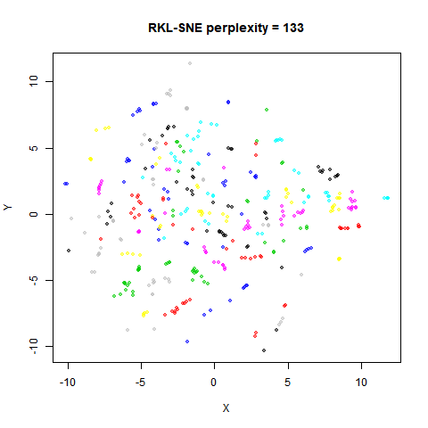

### frey

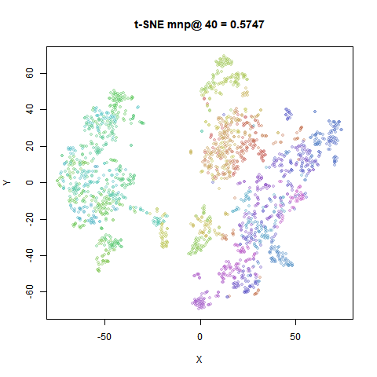

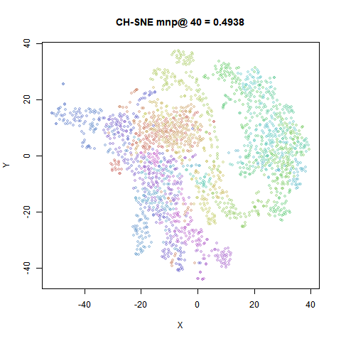

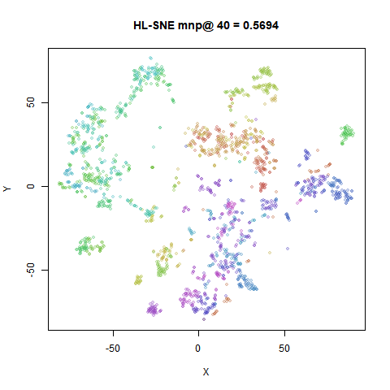

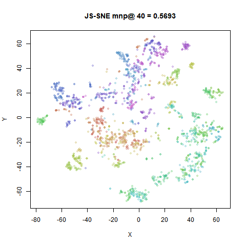

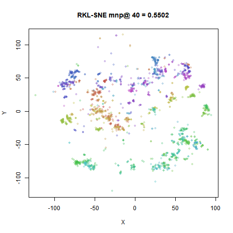

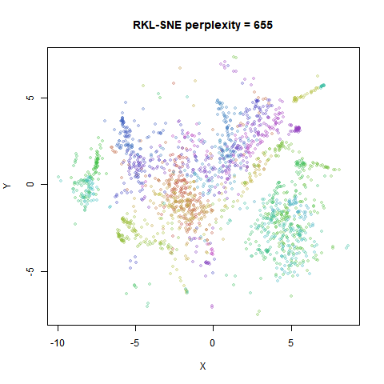

### coil20

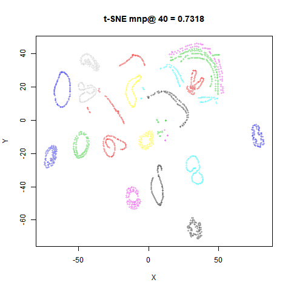

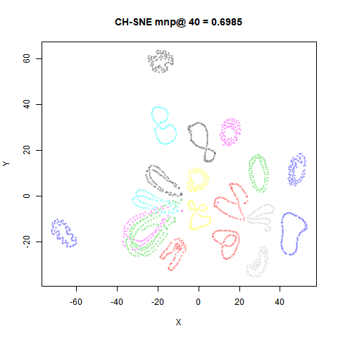

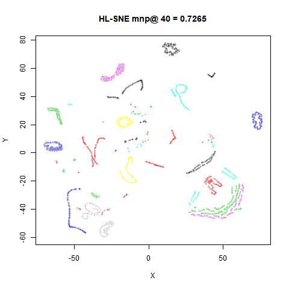

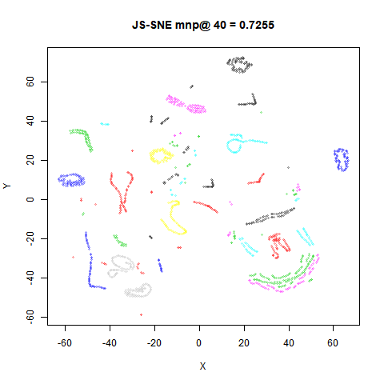

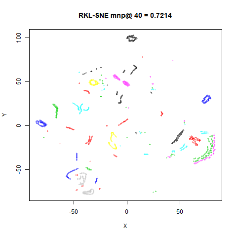

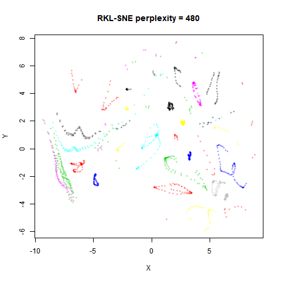